# New_processing_climatic_data_april_T_Adapcon_Gentree

Thomas Francisco

2024-04-29

```r
meta_data_pop <- read.csv("C:/Users/tfrancisco/Documents/Thèse/Data/Espèces/Taxus_baccata/Populations/taxus_sample_29pop.csv",h=T,sep=";",dec=",")
meta_data_vcf <- read.csv("C:/Users/tfrancisco/Documents/Thèse/Data/Espèces/Taxus_baccata/samples/samples_taxus_baccata_adapcon_gentree.csv",h=T,sep=";",dec=",")
```

This script is a pipeline to process the climatic/environmental data from the row output of *ClimateDT* (or any program that would give data in raster tif) to a dataframe with center and reduce the choosen variables for past/present and future climatic data.  
This script is separate in multiples steps:  
- Pre-selection of climatic variables and visualization between pop (see if adaptive gradients could emerge)  
- Loading climatic data and processing them  
- Selection of climatic variables: explained genetic variance, check multicollinearity between variables and VIF  
- Future climatic data: processing and comparison of the different climatic models - Standardization of the retained climatic values

**1. Pre-selection of climatic variables** The first step consisted of going through the literature of the targeted species and defined a set of climatic variables potentially drivers (inducing selective pressure) of adaptive genetic variation across the species range.  
The goal is to retain biological informative climatic variables only. This enable to reduce the set of tested climatic variables and also enable to work on the hypothesis before starting the analysis. The goal is not to retain only 2 or 3 variables but also not to retain 40 of them. This pre-selection could retain 10-15 variables depending on the species and the richness of the literature related to it.

For Taxus baccata, we retained as a first pre selection: **Bio 1,2,3,4,5,6,7,9,10,12,13,14,15,16,17,18,MGSP,AHM,SHM**.

**2. Loading climatic data and processing them** Climatic data are coming from **ClimateDT** in two different types: layer of points and raster. We extracted the data from the past and from the future. One major differences between past and future data results in the shape of the data: - Past data are available in 1 value per year for each variables (for each populations/pixel selected). As an example, for the period 1901-1950, we have 50 values for each variables for each populations - Future data are not so accurate, we only have the mean of the values for the selected period. As a example, for the period 2041-2070, we have 1 value for each variables for each populations.

One of the issues is that all the bioclimatic variables (bio) or other related climatic variables are build using monthly values of tmin, tmax and precipitation. We cannot just perform the mean of the 50 values of bio 1 from 1901 to 1950 to obtain the mean value of bio 1 for this period. We need to average the tmin, tmax and precipitation for each month to have 1 value of tmin for January for the period 1901-1950, 1 value of tmin for February for the period 1901-1950 … Then, we can use the **biovars** function from the **Dismo** R package to calculate the 19 bioclim variables for the period of interest (e.g 1901-1950). To calculate the other climatic variables such as AHM for the same specific period, we can follow the procedure of ClimateDT by using the new Bio1,Bio10 and Bio12… obtained from biovars. For other variables not directly linked to tmin, tmax, precipitation or bioclim variables such as GDD5, the average value for a specific period is not straightforward to get, data are coming from Maurizio Marchi (IBBR-CNR).

Also, only 1 model is available in CLimateDT for future data. Or, we know that climatic models depending on the method to estimate the future climate can predict different values. We could be interested in using the mean future climatic values of several climatic models to avoid selecting an extreme model along the range of predicted models for future climate. To use several climatic models, we can only have raster data.

[output not shown]

So based on these previous scripts, **we will use the 1901-1950 period and raster data because the differences between raster values and layer of points are important for temperature related climatic variable. Indeed, for future data we need to use the raster as explained previously so it’s better if we use also raster data for past climatic data to avoid differences in climate linked to the method of extraction.**

```
  - Load the past climatic data
```

```r
#create an R object where all the climatic rasters are.
ras.bio <- stack(list.files("C:/Users/tfrancisco/Documents/Thèse/Data/Climatic/1901-1950_raster/", pattern = ".tif$", full.names = T))
#names of the raster (because they are not in the classic order Bio 1, 2 etc they are order by number so bio 1, 10, 11 etc)
names(ras.bio) <- unlist(strsplit(unlist(lapply(strsplit(list.files("C:/Users/tfrancisco/Documents/Thèse/Data/Climatic/1901-1950_raster/", pattern = ".tif$", full.names = T), split = "C:/Users/tfrancisco/Documents/Thèse/Data/Climatic/1901-1950_raster/"), function(x) x[2])), split = ".tif"))


#we extracted the climatic values for each populations from the raster based on their coordinates
coords<- data.frame(apply(meta_data_pop[,c(5:4)], 2, as.numeric))#we need to have longitude then latitude
past_climatic_data_raster <- data.frame(meta_data_pop$Population,raster::extract(ras.bio, coords))#important to add raster:: because this function is also in tidyr and will not do the same things
colnames(past_climatic_data_raster)<- c("Population",names(ras.bio))

#add country info
past_climatic_data_f <- merge(meta_data_pop[,c(1,2)],past_climatic_data_raster, "Population")
```

```
  - Variation of the variables between populations
```

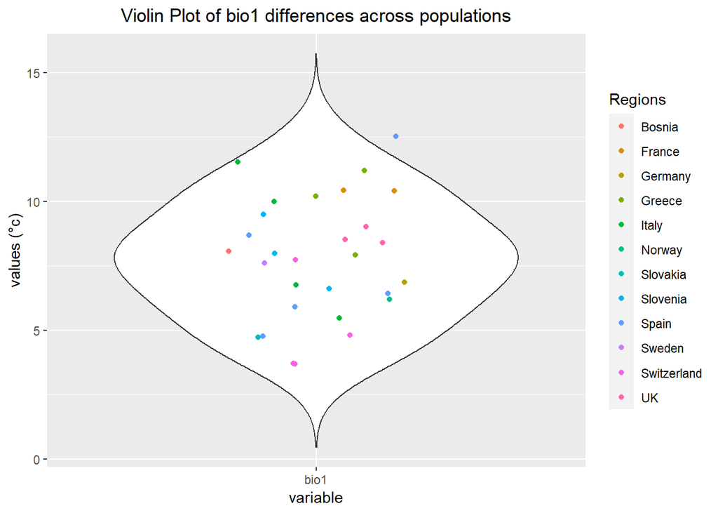

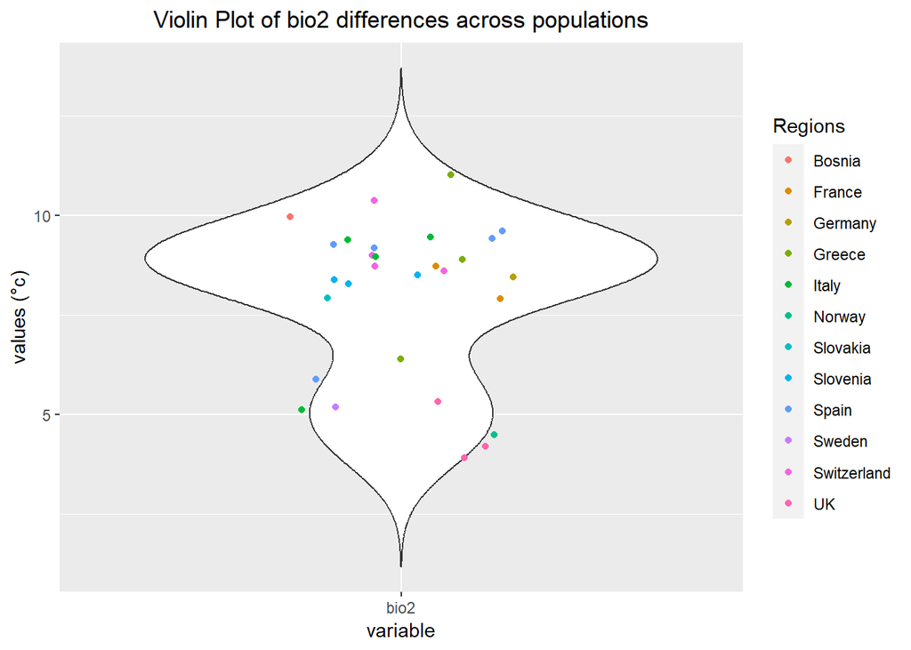

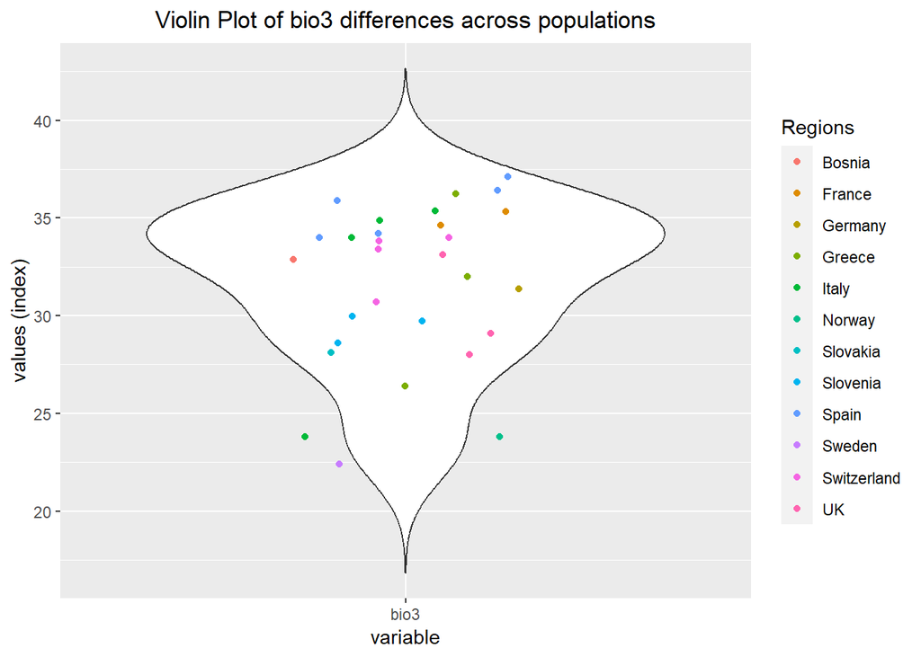

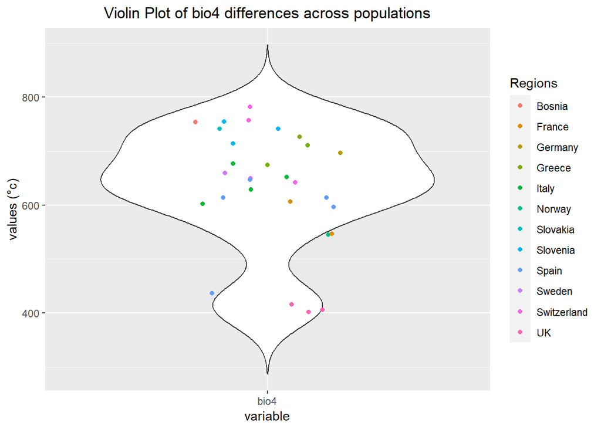

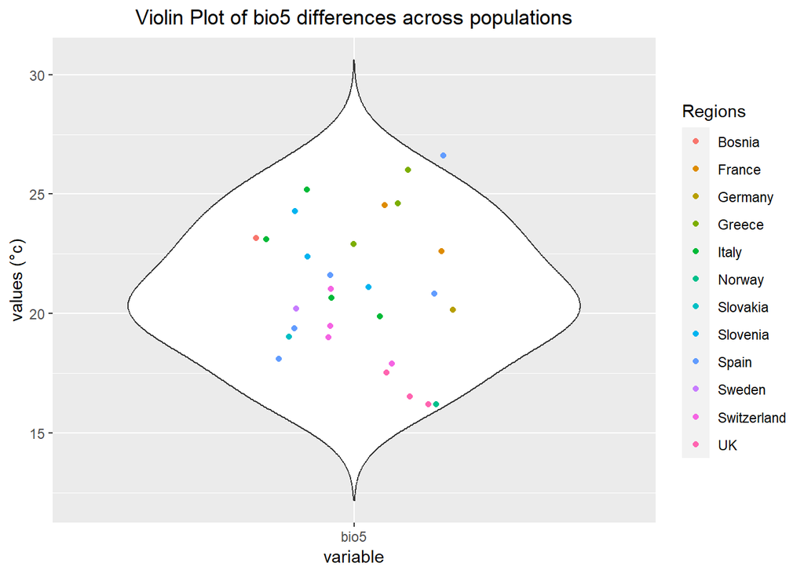

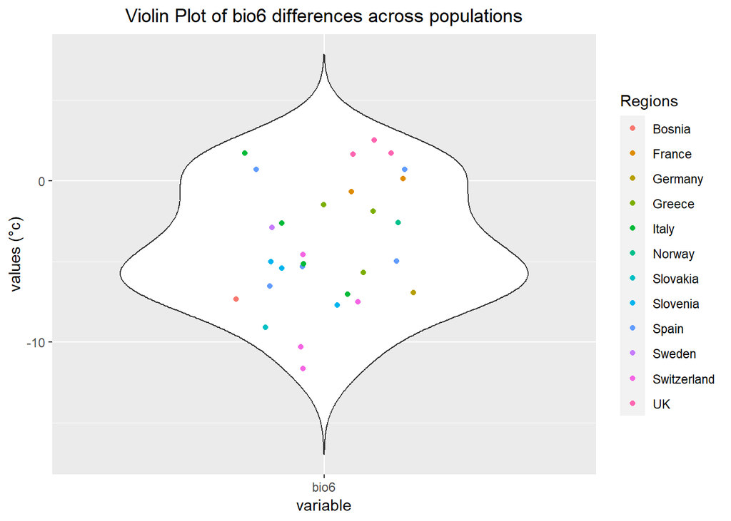

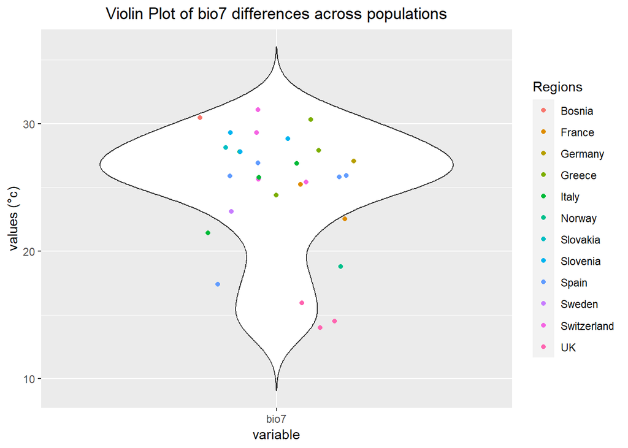

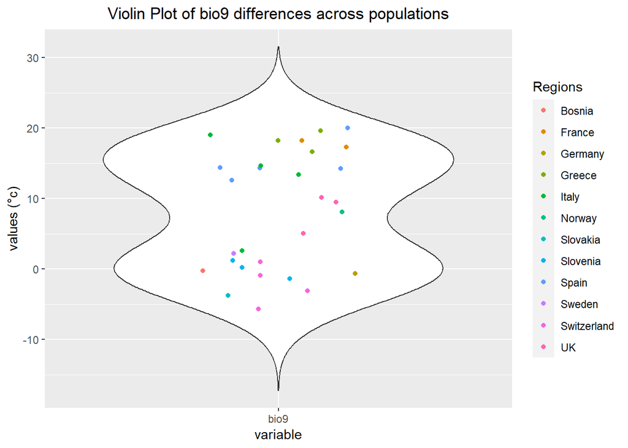

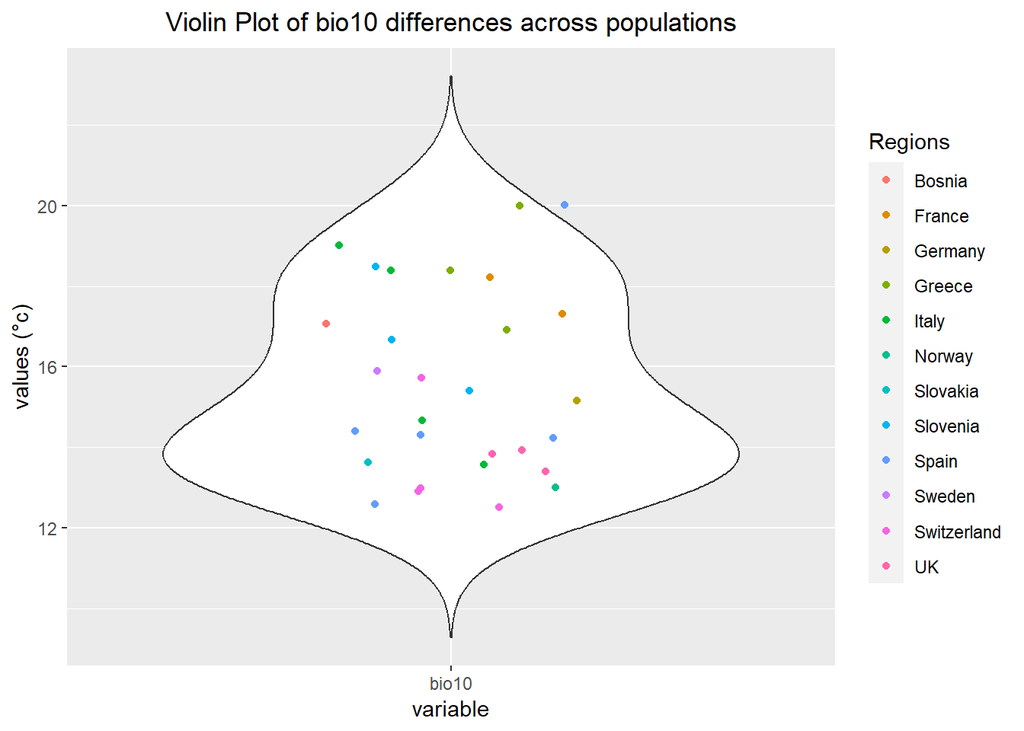

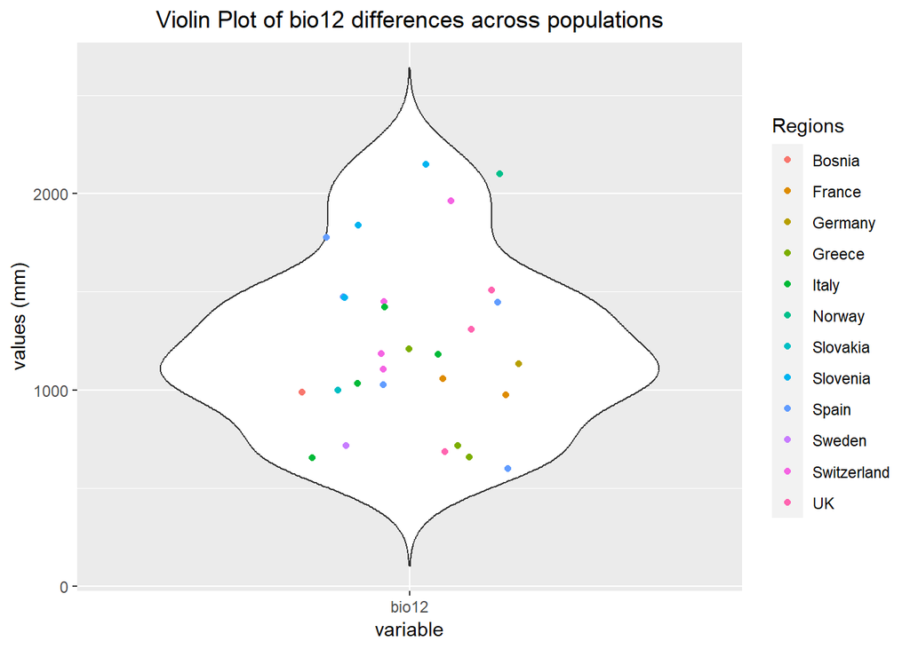

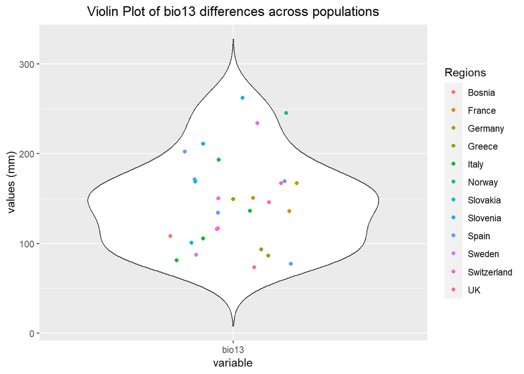

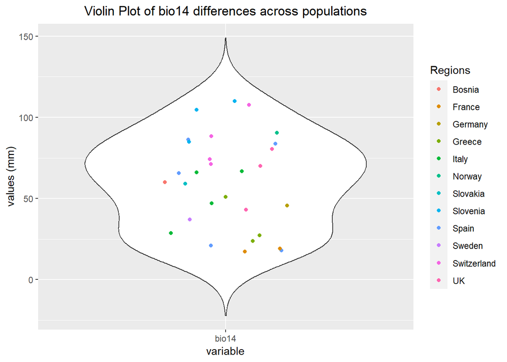

[8 more figures not shown]

```r
#do the violin plot in a loop for each climatic variables

#input data for the loop
data <- past_climatic_data_f
regions <-past_climatic_data_f$Country
bioclim_vars <- c("bio1", "bio2", "bio3", "bio4","bio5","bio6","bio7","bio9", "bio10","bio12","bio13","bio14","bio15","bio16", "bio17", "bio18","AHM", "MGSP", "SHM", "GDD5")
unit_var <- c("°c","°c","index","°c","°c","°c","°c","°c","°c","mm","mm","mm","index","mm","mm","mm","°c/mm","mm","°c/mm","°c*days" )

#results: the loop
for (x  in 1:length(bioclim_vars)) {
  var <- bioclim_vars[x]
   unit <- unit_var[x]
  data_subset <- data.frame(data[, paste0(var)]) #for each variable in bioclim_vars, we extract the two periods and created a data.frame with only these two variables.
  colnames(data_subset) <- c("var1")
  # Create scatterplot to compare the bioclimatic variable between the two periods
  plot <- ggplot(data_subset, aes(x =var,y= var1)) +#var is the values and var1 is just the name of the variable
  geom_violin(trim = FALSE) +
  geom_point(aes(color = regions), shape = 16, position = position_jitter(seed = 1, width = 0.2)) +
  labs(colour="Regions",x="variable",y=paste0("values ","(",unit,")"),title=paste0("Violin Plot of ",var," differences across populations"))+
  theme(plot.title = element_text(hjust = 0.5))

  # Add any additional customization or saving the plot if needed
png(paste0("C:/Users/tfrancisco/Documents/Thèse/Results/species/taxus/climate/past_climatic_data/violin_plot/violin_plot_",var,".png"));print(plot)
;dev.off()

# Print the plot
  print(plot)
}
```

Interpretation: We could see differences of climatic values across populations. Conclusion: This could suggest that local adaptation could be found because their seems to have different climatic selective pressure across the populations.

**3. Selection of climatic variables**

Selection of climatic variables will be in 2/3 steps:

```
i. Difference between past and future values
```

We will not do this step because if the variables are not changing into the future that is also an information that the climate change will not impact much this species or these populations if some of them are very locally adapted to a variable that will not change.

```
  ii. Imprecision along studied area
```

Accuracy of the climatic variables is not homogeneous along the studied area and also along the climatic variables. If layers of uncertainty are available, we could check if some variables have a high inaccuracy along the studied area and then remove them.  
-> Not possible for now, keep in mind.

```
  iii. Explained variance
```

In this step, we want to see which variables explained the most the genetic variation.  
To do this, we will perform a Redundancy Analysis(RDA, see explanation of the method in the script RDA_candidate_detection).  
We need the genomic data

```r
#genomic data
load("C:/Users/tfrancisco/Documents/Thèse/Data/Espèces/Taxus_baccata/genetic_new/data_allelic_frequencies_29pop_adapcon_gentree_475_8616.Rdata")

genomic_matrix <- data_allelic_frequencies_29pop_adapcon_gentree_475_8616
```

We also need to scale the climatic var:

```r
past_climatic_data_scale <- past_climatic_data_f[,-c(1,2)]%>%
  apply(2,as.numeric) %>% as.data.frame %>%
mutate(across(where(is.numeric), scale))
```

We can perform the RDA:

```r
#null model
RDA_null <- rda(genomic_matrix~1,past_climatic_data_scale )

#model with all the variables
RDA_full <- rda(
formula=genomic_matrix~bio1+bio2+bio3+bio4+bio5+bio6+bio7+bio9+bio10+bio12+bio13+bio14+bio15+bio16+bio17+bio18+AHM+MGSP+SHM+GDD5,data = past_climatic_data_scale,scale=F)

#stepwise by selecting only variables that increase the adjusted R^2 of the model and that have a pvalue lower than 0.05
#Variable_selection_pv0.05 <- ordiR2step(RDA_null, RDA_full, Pin = 0.05, R2permutations = 1000, R2scope = T)

#Variable_selection_pv0.05$anova

#we want, following Archambeau et al 2024, investigate if the permutation stepwise identified the same variables of interest depending on the run:
#we run 20 independent stepwise models.
nbmodels <- 20

# Stepwise selection with ordiR2step function
#rep20_variable_selec_pv0.05 <- lapply(1:nbmodels, function(x) {
#  mod <- ordiR2step(RDA_null, RDA_full, Pin = 0.05, R2permutations = 1000, R2scope = T)
#  return(names(mod$CCA$envcentre))}) %>%
#  setNames(paste0("model",1:nbmodels)) %>%
#  ldply(function(x) data.frame(variables=x),.id="models") %>%
#  dplyr::summarise(count(variables)) %>%
#  setNames(c("variable","count"))
```

```r
rep20_variable_selec_pv0.05
```

```
##   variable count
## 1     bio2    20
## 2     bio4    20
## 3     bio7    20
## 4     bio9    20
```

Interpretation: Bio 2, 4, 7 and 9 seems to be important. They are all identified 20 out of the 20 runs of ordi2steps by increasing the R^2 if the models with a pvalues < 0.05. Conclusion: According to the stepwise analysis, BIO 2, 4, 7 and 9 seems to be of interest to explain the genetic variation.

```
  iv. Multicollinerity between variables
```

Here, we want to select the variables with low collinearity between them. To do so, we decided to keep only the variables not too correlated (<absolute corr of 0.75) from the remaining variables after step 1.

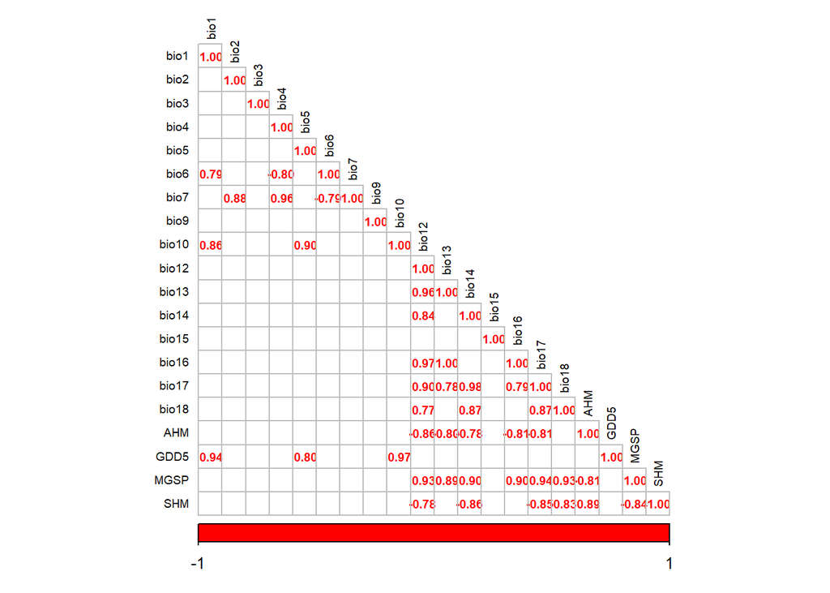

```r
#function to do it
#matrix of correlation
correlation_function <-function(data,threshold){
    data_correlation <- subset(data,select= -c(Population,Country))
      rownames(data_correlation) <- data$Populations
      correlation <- cor(data_correlation)
  correlation[abs(correlation) <= threshold] <- 0
corr_plot <- corrplot(correlation, method = "number", addrect = 2, col = c("red", "white", "red"), type = "lower", tl.col = "black", tl.cex = 0.6, number.cex = 0.6)
#save
png("C:/Users/tfrancisco/Documents/Thèse/Results/species/taxus/climate/selection_var/corrplot_multicollinearity.png");corr_plot <- corrplot(correlation, method = "number", addrect = 2, col = c("red", "white", "red"), type = "lower", tl.col = "black", tl.cex = 0.6, number.cex = 0.6);dev.off()

#plot the corrplot
corr_plot
}

#right order
past_climatic_data_order <- past_climatic_data_f[,c(1,2,4,13:19,5:12,3,20,21,22)]

#correlation past/present
data_present <- past_climatic_data_order #we use the dataset without the variables we discarded previously
threshold <- 0.75
correlation_past <-correlation_function(data_present,threshold)
```

Conclusion: Based on the correlation between variable and step 3, we can select **BIO 1, 2, 3, 4, 5, 9, 12, 15**

```
  v. VIF:
```

We want to test the inflation factor between variables retained to be sure that we do not take overcorrelated variables

```r
#subset step 4
RDA_subset_step4 <- rda(formula=genomic_matrix~bio1+bio2+bio3+bio4+bio5+bio9+bio12+bio15,data = past_climatic_data_scale,scale=F)
#anova.cca(RDA_subset_step4)
#RsquareAdj(RDA_subset_step4)
##vif
vif.cca(RDA_subset_step4)
```

```
##       bio1       bio2       bio3       bio4       bio5       bio9      bio12
##  28.981154 166.091110  64.987887  65.456002  46.882875   3.491931   1.427049
##      bio15
##   1.769682
```

Interpretation: We can see that the VIF of some variable in the subset coming from step 4 is too high (over 160 for bio2). Based on that and the information that some variables are of interest to explain the genetic variation, we adjusted the subset to lower the VIF (below 10)

```r
#adjusted subset based on VIF
RDA_adjusted_subset <- rda(formula=genomic_matrix~bio1+bio2+bio4+bio9+bio12+bio15,data = past_climatic_data_scale,scale=F)
#anova.cca(RDA_adjusted_subset)
#RsquareAdj(RDA_adjusted_subset)
##vif
vif.cca(RDA_adjusted_subset)
```

```
##     bio1     bio2     bio4     bio9    bio12    bio15
## 1.861089 2.470835 2.780922 2.708000 1.357544 1.768915
```

Interpretation: We can see that by removing BIO 5 and 3, we lowered the VIF to less than 3 for all the retained variables. Conclusion: we retained the subset: **BIO 1, 2, 4, 9, 12, 15** : - Bio 1: Mean annual Temperature (°C) - Bio 2: Mean Diurnal Range (Mean of monthly (max temp - min temp)) (°C) - Bio 4: Temperature Seasonality (standard deviation x100) (°C) - Bio 9: Mean Temperature of Driest Quarter (°C) - Bio 12: Mean annual Precipitation (mm) - Bio 15: Precipitation Seasonality (mm)

**4. Future climatic data: processing and comparison of the different climatic models**

Multiple climatic models that predict the future climate are available. Choosing one of them could lead to imprecision because sometimes the difference in prediction are important. To avoid bias by selecting only one climatic model that could be an extreme, we selected 5 of them for the future data. We want to compare them to see if there is a lot a differences in predictions between models. As future climatic data, we chosen the 2041-2070 period for the SSP 3.7.0 scenario.As for climatic models, we did not have any prior information to guide the choice, then we selected 5 of the most used climatic models: - GFDL-ESM4  
- IPSL-CM6A-LR  
- MPI-ESM1-2-HR - MPI-ESM2-0  
- UKESM1-0-LL

The first step is to load the future climatic data for each climatic model

```r
#list of the model for the loop
list_models<- c("GFDL_ESM4","IPSL_CM6A_LR","MPI_ESM1_2_HR","MPI_ESM2_0","UKESM1_0_LL")

for(x in 1:length(list_models)){

  model <- list_models[x]
  #create an R object where all the climatic rasters are
ras.bio <- stack(list.files(paste0("C:/Users/tfrancisco/Documents/Thèse/Data/Climatic/Future_climate/2041_2070_",model,"_ssp370/"), pattern = ".tif$", full.names = T))
#names of the raster (because they are not in the classic order Bio 1, 2 etc they are order by number so bio 1, 10, 11 etc)
names(ras.bio) <- unlist(strsplit(unlist(lapply(strsplit(list.files(paste0("C:/Users/tfrancisco/Documents/Thèse/Data/Climatic/Future_climate/2041_2070_",model,"_ssp370/"), pattern = ".tif$", full.names = T), split = paste0("C:/Users/tfrancisco/Documents/Thèse/Data/Climatic/Future_climate/2041_2070_",model,"_ssp370/")), function(x) x[2])), split = ".tif"))

future_climatic_data <- data.frame(meta_data_pop$Population,raster::extract(ras.bio, coords))
colnames(future_climatic_data)=c("Population",names(ras.bio))
new_colnames<- paste(colnames(future_climatic_data[,-1]),model, sep = "_")
colnames(future_climatic_data)[-1] <- new_colnames

#add country info
future_climatic_data_f <- merge(meta_data_pop[,c(1,2)],future_climatic_data, "Population")

assign(paste0("Future_data_",model), future_climatic_data_f)
}
```

The next step is to group by climatic variables the data across climatic models

```r
#list of the climatic var
list_climatic_var <- c("bio1","bio12","bio15","bio2","bio4","bio9")

for(x in 1:length(list_climatic_var)){
  climatic_var <- list_climatic_var[x]

  pos_clim <- x+2

  #climatic_values_ff <- Future_data_GFDL_ESM4[,x]

  data_set_clim <- data.frame(Population=Future_data_GFDL_ESM4$Population,Country=Future_data_GFDL_ESM4$Country,Future_data_GFDL_ESM4[,pos_clim],Future_data_IPSL_CM6A_LR[,pos_clim],Future_data_MPI_ESM1_2_HR[,pos_clim],Future_data_MPI_ESM2_0[,pos_clim],Future_data_UKESM1_0_LL[,pos_clim])

  colnames(data_set_clim)<- c("Population","Country",paste0(climatic_var,"_GFDL_ESM4"),paste0(climatic_var,"_IPSL_CM6A_LR"),paste0(climatic_var,"_MPI_ESM1_2_HR"),paste0(climatic_var,"_MPI_ESM2_0"),paste0(climatic_var,"_UKESM1_0_LL"))

  assign(paste0(climatic_var,"_future_climatic_data"),data_set_clim)
}
```

Then, we can plot in violin plot, the climatic values of each populations with each climatic models. We can do a graph per bioclimatic variable of interest.

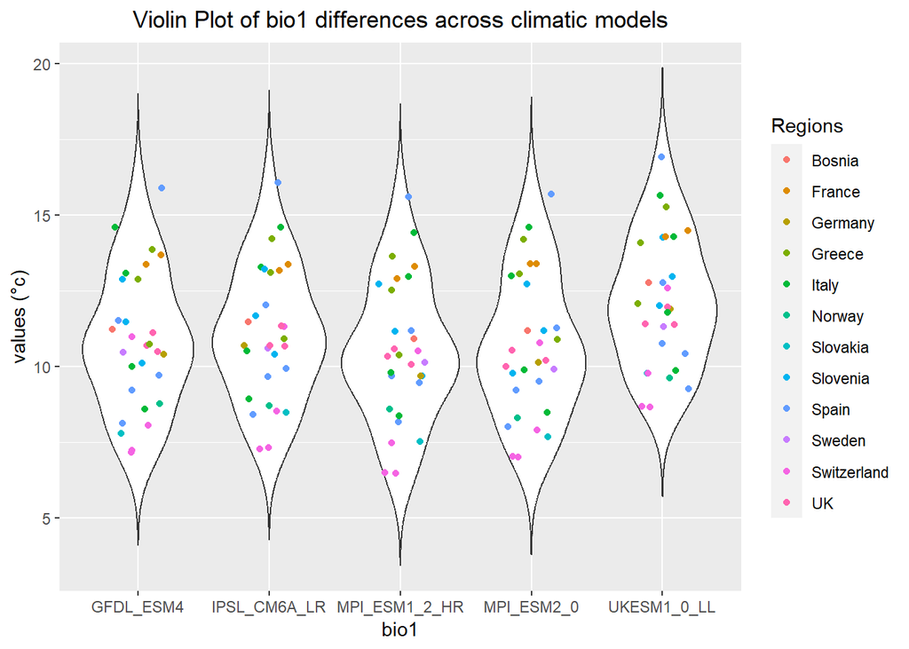

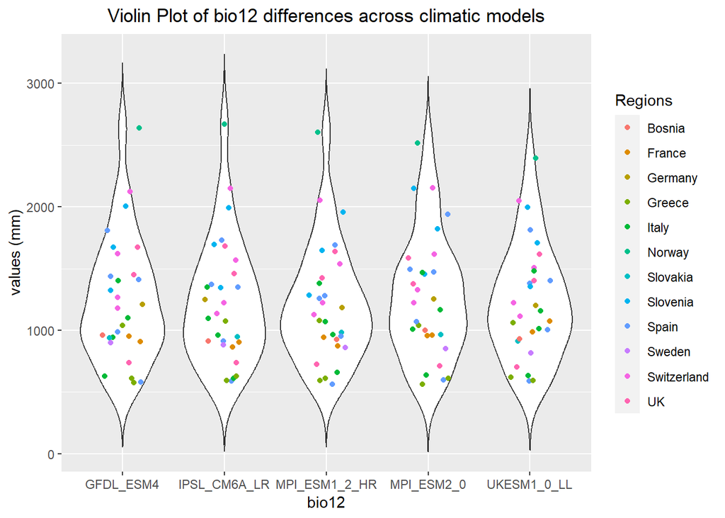

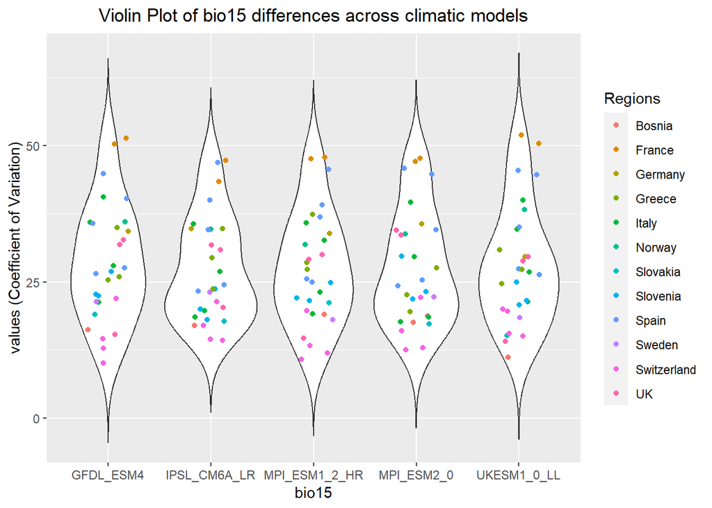

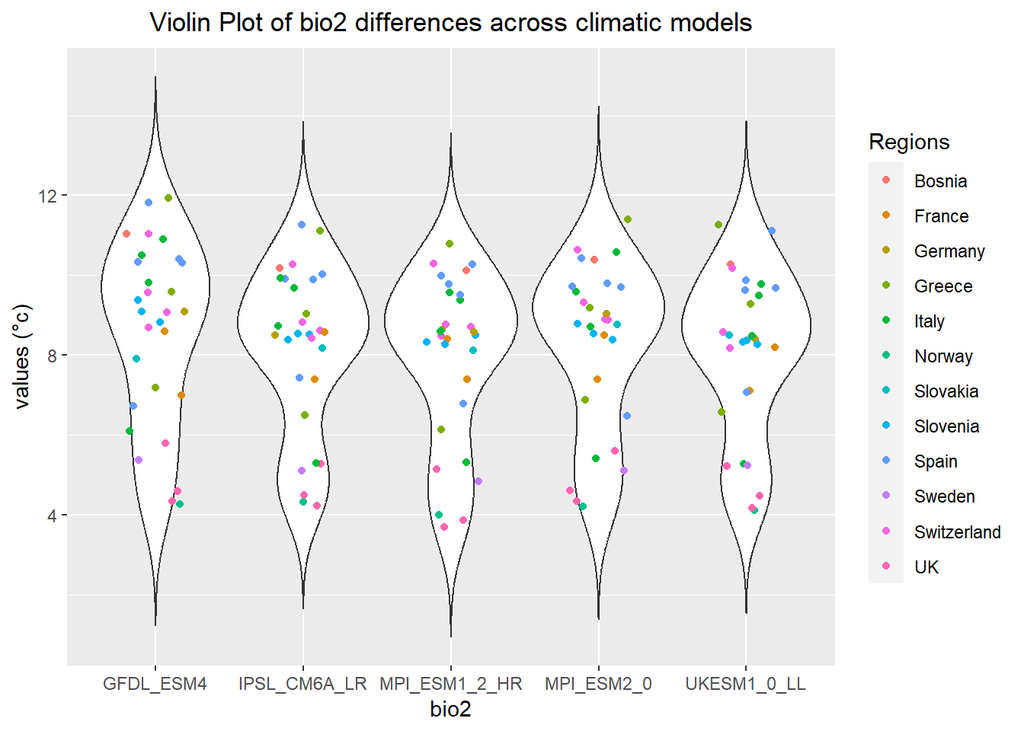

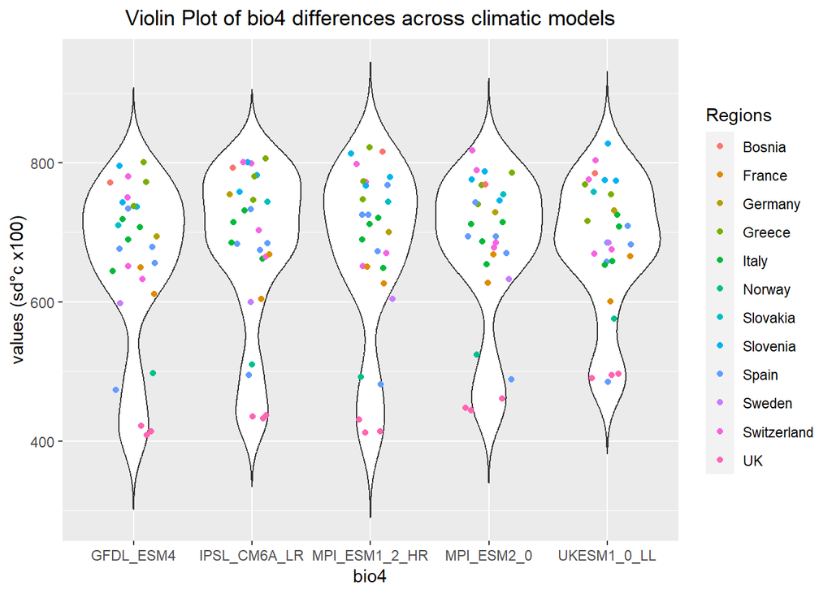

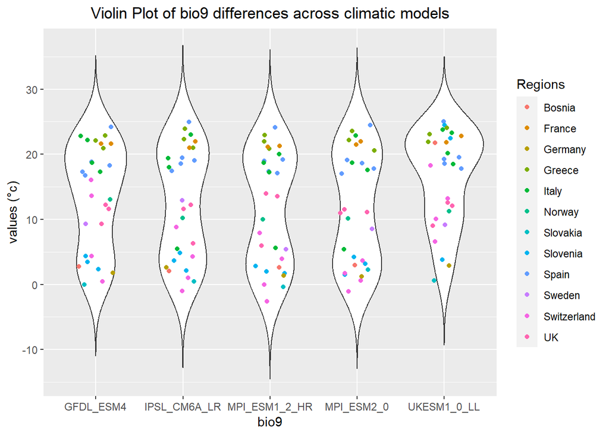

```r
#input data for the loop
unit_var <- c("°c","mm","Coefficient of Variation","°c","sd°c x100","°c")
list_dataset <- c("bio1_future_climatic_data","bio12_future_climatic_data","bio15_future_climatic_data","bio2_future_climatic_data","bio4_future_climatic_data","bio9_future_climatic_data")

#results: the loop
for (x  in 1:length(list_dataset)) {

  dataset <- get(list_dataset[x])
   unit <- unit_var[x]
var_name <- list_climatic_var[x]

data_violin <- gather(dataset,key="dataset",value="Value",-Population,-Country)

#add the name of the model
data_violin_f <- data_violin %>%
  mutate(models = gsub("^[^_]+_", "", dataset))


  # Create scatterplot to compare the bioclimatic variable between the two periods
  plot <- ggplot(data_violin_f, aes(x = models,y= Value)) +
  geom_violin(trim = FALSE) +
  geom_point(aes(color = data_violin_f$Country), shape = 16, position = position_jitter(seed = 1, width = 0.2)) +
  labs(colour="Regions",x=var_name,y=paste0("values ","(",unit,")"),title=paste0("Violin Plot of ",var_name," differences across climatic models"))+
  theme(plot.title = element_text(hjust = 0.5)) +
     scale_x_discrete(labels = c("label1" = "name1", "label2" = "name2"))

#save
png(paste0("C:/Users/tfrancisco/Documents/Thèse/Results/species/taxus/climate/future_climatic_data/violin_plot_comp_models/Comparison_",var_name,"between_climatic_models.png"));print(plot)
;dev.off()

# Print the plot
  print(plot)
}
```

We can see that there is some differences between climatic models but globally, the values seems quite close.  
To test if the values are similar, we will calculate correlation matrix

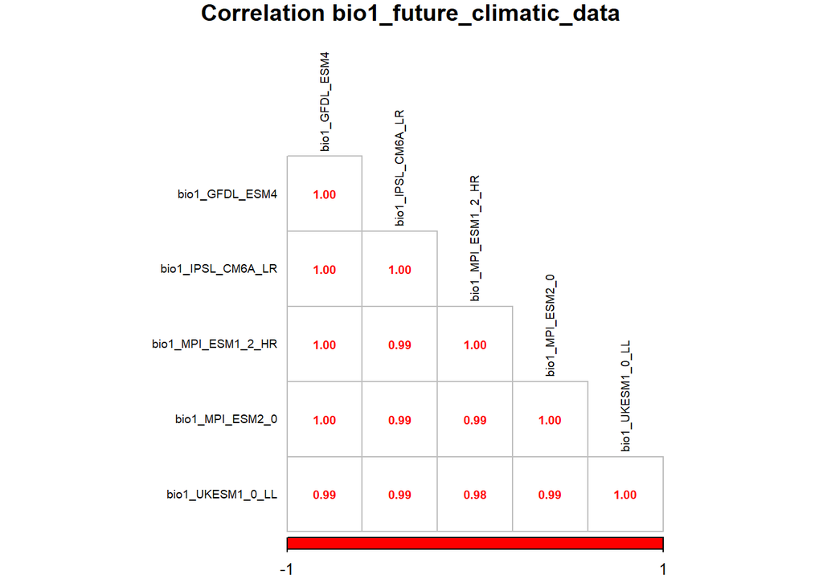

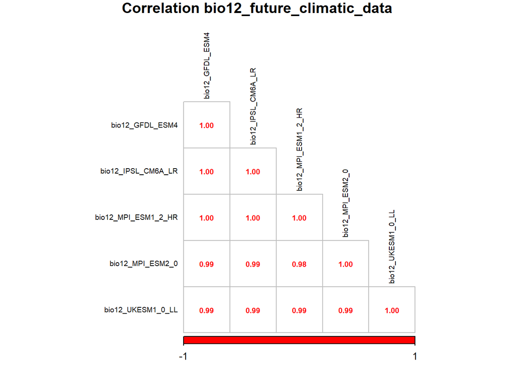

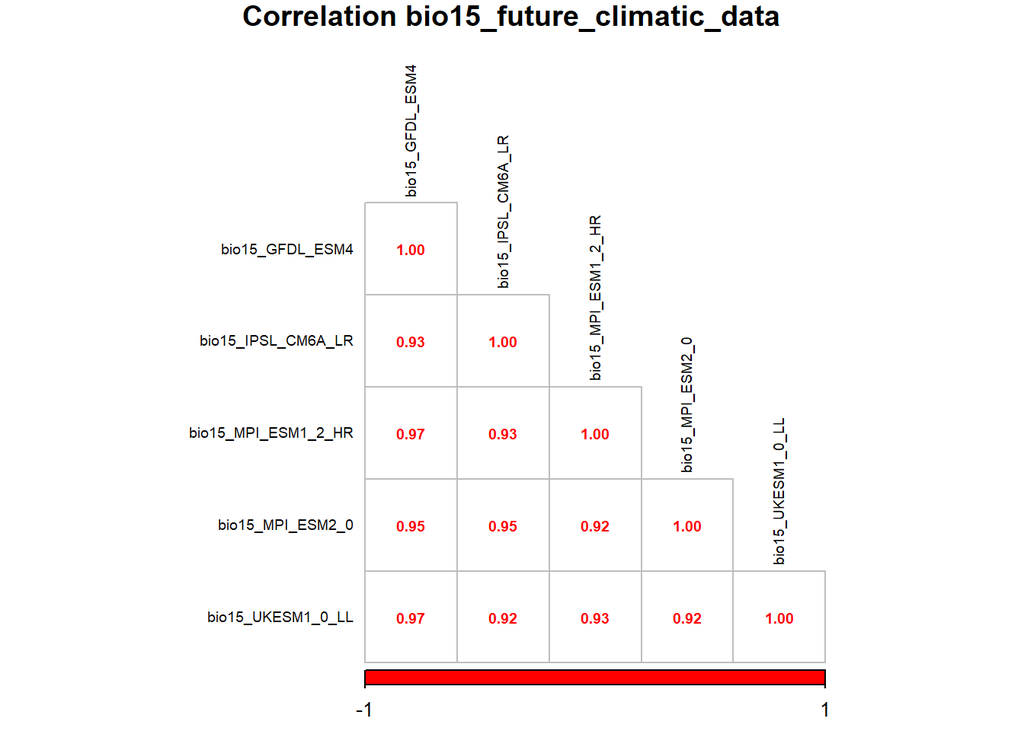

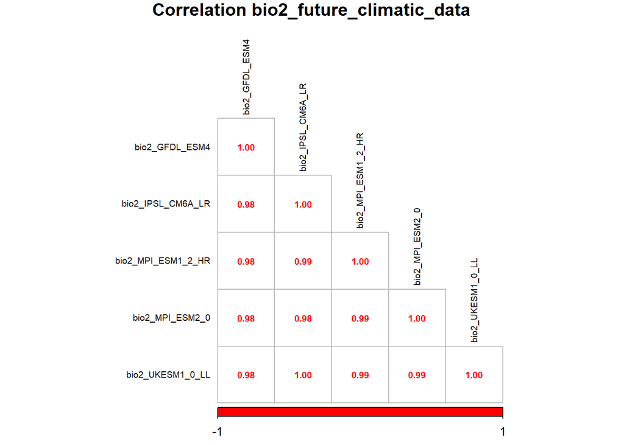

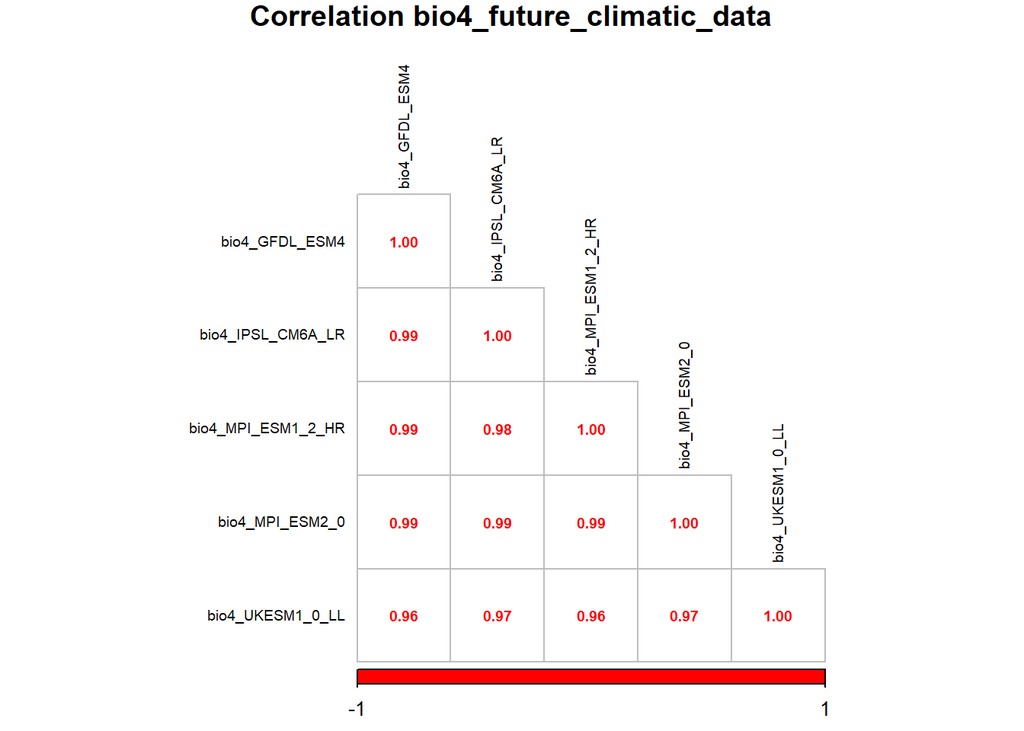

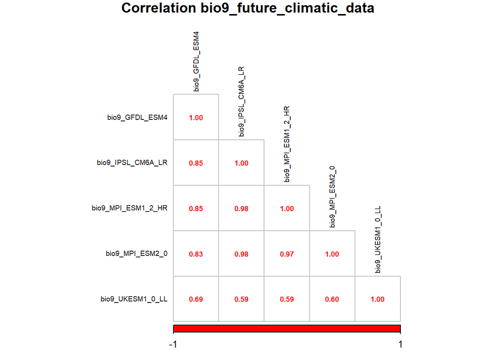

```r
for(x in 1:length(list_dataset)){
  df <- get(list_dataset[x])

  df_num <- df[,-c(1,2)] %>% mutate(across(as.numeric))

  #names of the corr matrix for each biovariable
  names_corr <- paste0("correlation_",list_dataset[x])
  #title of corrplot
  title <- (paste0("Correlation ",list_dataset[x]))



  #group for each bio var with the values of Bayes factor only
corr_bio <- cor(df[, grepl("bio", names(df))])

#name the corr_bio with names_corr
assign(names_corr,corr_bio)

#plot corrplot
corr_plot <- corrplot(get(names_corr), method = "number", addrect = 2, col = c("red", "white", "red"), type = "lower", tl.col = "black", tl.cex = 0.6, number.cex = 0.6, title = title,mar=c(0,0,1,0) )

#save
png(paste0("C:/Users/tfrancisco/Documents/Thèse/Results/species/taxus/climate/future_climatic_data/Correlation/correlation_",list_dataset[x],".png"));corr_plot <- corrplot(get(names_corr), method = "number", addrect = 2, col = c("red", "white", "red"), type = "lower", tl.col = "black", tl.cex = 0.6, number.cex = 0.6, title = title,mar=c(0,0,1,0) );dev.off()
}
```

The climatic values are very similar across climatic models except for BIO 9 where the UKESM1_0_LL predict values very inconsistent from what is predicted by other models. This is a reminder that due to an absence of prior information suggesting one model over the others, we should be careful when selecting the future climatic values. Here, we will use as future values, the mean values of the 5 climatic models.

```r
for (x in 1: length(list_dataset)){
  var <- list_climatic_var[x]
   dataset <- get(list_dataset[x])

df <- dataset %>%
  mutate(mean_values=rowMeans(dplyr::select(., 3:7)))

df_f <- df[,c(1,2,8)]
colnames(df_f) <- c("Population","Country",paste0("mean_values_",var))

assign(paste0("df_",var,"_mean"),df_f)
}
```

```r
Future_climatic_data_T_adapcon_gentree<- data.frame(Population=df_bio1_mean[,1],Country=df_bio1_mean[,2],Annual_Tc=df_bio1_mean[,3],Diurnal_range_Tc=df_bio2_mean[,3],Tc_Seasonality=df_bio4_mean[,3],Tc_driest_quarter=df_bio9_mean[,3],Annual_P=df_bio12_mean[,3],P_Seasonality=df_bio15_mean[,3])
```

**6. Standardization of the retained climatic values**

The final step is to create a data frame with the retained climatic variables standardized for further analysis. We standardized the past and future data with the same values to enable comparison of indexes between past and future based on the climatic data (e.g Adaptive index, genomic offset…)

```r
#creation of the scaled matrix

Past_new_6_Climatic_data_scale <-past_climatic_data_order[,c(3,4,6,10,12,15)] %>%
    scale()


Past_new_6_Climatic_data_scale_df <- data.frame(past_climatic_data_order[,c(1,2)],Past_new_6_Climatic_data_scale)

colnames(Past_new_6_Climatic_data_scale_df) <- c("Population","Country","Annual_Tc","Diurnal_range_Tc","Tc_Seasonality","Tc_driest_quarter","Annual_P","P_Seasonality")


df_to_scale <- past_climatic_data_order[,c(3,4,6,10,12,15)]
colnames(df_to_scale) <- c("Annual_Tc","Diurnal_range_Tc","Tc_Seasonality","Tc_driest_quarter","Annual_P","P_Seasonality")

  scale_env_value_new_cli <- attr(scale(df_to_scale), 'scaled:scale')
center_env_value_new_cli <- attr(scale(df_to_scale), 'scaled:center')
```

We finally can scale the future climatic data using the mean and sd of the past climatic data.

```r
load("C:/Users/tfrancisco/Documents/Thèse/Data/Espèces/Taxus_baccata/Climatic_data/new_selection/scale_env_value_new_cli.Rdata")
load("C:/Users/tfrancisco/Documents/Thèse/Data/Espèces/Taxus_baccata/Climatic_data/new_selection/center_env_value_new_cli.Rdata")

Future_climatic_data_T_adapcon_gentree_scaled <- data.frame(Future_climatic_data_T_adapcon_gentree[,c(1,2)],scale(Future_climatic_data_T_adapcon_gentree[,-c(1,2)], center = center_env_value_new_cli, scale = scale_env_value_new_cli))
```

We also for LFMM analysis, have to do a dataframe with climatic values at the individual level: with individuals of the same pop having the same climatic values.

```r
#load meta_data at individual level

climatic_data_indivdual_level_new_selection <- merge(meta_data_vcf[,-2],past_climatic_data_order[,c(1:4,6,10,12,15)],"Population")

climatic_data_indivdual_level_scaled_new_selection <- climatic_data_indivdual_level_new_selection[,-c(1:3)] %>%
  scale()

climatic_data_indivdual_level_scaled_new_selection_df <- data.frame(climatic_data_indivdual_level_new_selection[,c(1:3)],climatic_data_indivdual_level_scaled_new_selection)

#rename columns
colnames(climatic_data_indivdual_level_scaled_new_selection_df) <- c("Population","VCF_ID","Country","Annual_Tc","Diurnal_range_Tc","Tc_Seasonality","Tc_driest_quarter","Annual_P","P_Seasonality")
```